# Risk Factor Analysis

## Outcome Variable

**Outcome Variable:** sstunted

## Predictor Variables

**Intervention Variable:** mwtkg

**Adjustment Set:**

- arm
- W_mage
- W_fage
- meducyrs
- feducyrs
- single
- brthmon
- delta_W_mage
- delta_W_fage
- delta_meducyrs
- delta_feducyrs
- delta_single
- delta_brthmon

## Stratifying Variables

The analysis was stratified on these variable(s):

- agecat
- studyid
- country

## Data Summary

| agecat | studyid | country | mwtkg | sstunted | n_cell | n |
| --- | --- | --- | --- | --- | --- | --- |
| Birth | ki0047075b-MAL-ED | BANGLADESH | >=58 kg | 0 | 47 | 246 |
| Birth | ki0047075b-MAL-ED | BANGLADESH | >=58 kg | 1 | 0 | 246 |
| Birth | ki0047075b-MAL-ED | BANGLADESH | <52 kg | 0 | 149 | 246 |
| Birth | ki0047075b-MAL-ED | BANGLADESH | <52 kg | 1 | 7 | 246 |
| Birth | ki0047075b-MAL-ED | BANGLADESH | [52-58) kg | 0 | 43 | 246 |
| Birth | ki0047075b-MAL-ED | BANGLADESH | [52-58) kg | 1 | 0 | 246 |
| Birth | ki0047075b-MAL-ED | BRAZIL | >=58 kg | 0 | 115 | 184 |
| Birth | ki0047075b-MAL-ED | BRAZIL | >=58 kg | 1 | 6 | 184 |
| Birth | ki0047075b-MAL-ED | BRAZIL | <52 kg | 0 | 33 | 184 |
| Birth | ki0047075b-MAL-ED | BRAZIL | <52 kg | 1 | 0 | 184 |
| Birth | ki0047075b-MAL-ED | BRAZIL | [52-58) kg | 0 | 28 | 184 |
| Birth | ki0047075b-MAL-ED | BRAZIL | [52-58) kg | 1 | 2 | 184 |
| Birth | ki0047075b-MAL-ED | INDIA | >=58 kg | 0 | 36 | 198 |
| Birth | ki0047075b-MAL-ED | INDIA | >=58 kg | 1 | 0 | 198 |
| Birth | ki0047075b-MAL-ED | INDIA | <52 kg | 0 | 118 | 198 |
| Birth | ki0047075b-MAL-ED | INDIA | <52 kg | 1 | 5 | 198 |
| Birth | ki0047075b-MAL-ED | INDIA | [52-58) kg | 0 | 37 | 198 |
| Birth | ki0047075b-MAL-ED | INDIA | [52-58) kg | 1 | 2 | 198 |
| Birth | ki0047075b-MAL-ED | NEPAL | >=58 kg | 0 | 56 | 172 |
| Birth | ki0047075b-MAL-ED | NEPAL | >=58 kg | 1 | 1 | 172 |
| Birth | ki0047075b-MAL-ED | NEPAL | <52 kg | 0 | 47 | 172 |
| Birth | ki0047075b-MAL-ED | NEPAL | <52 kg | 1 | 5 | 172 |
| Birth | ki0047075b-MAL-ED | NEPAL | [52-58) kg | 0 | 63 | 172 |
| Birth | ki0047075b-MAL-ED | NEPAL | [52-58) kg | 1 | 0 | 172 |
| Birth | ki0047075b-MAL-ED | PERU | >=58 kg | 0 | 96 | 276 |
| Birth | ki0047075b-MAL-ED | PERU | >=58 kg | 1 | 3 | 276 |
| Birth | ki0047075b-MAL-ED | PERU | <52 kg | 0 | 104 | 276 |
| Birth | ki0047075b-MAL-ED | PERU | <52 kg | 1 | 3 | 276 |
| Birth | ki0047075b-MAL-ED | PERU | [52-58) kg | 0 | 69 | 276 |
| Birth | ki0047075b-MAL-ED | PERU | [52-58) kg | 1 | 1 | 276 |

[output cut: 216 more lines]

The following strata were considered:

- agecat: 24 months, studyid: ki0047075b-MAL-ED, country: BANGLADESH
- agecat: 24 months, studyid: ki0047075b-MAL-ED, country: BRAZIL
- agecat: 24 months, studyid: ki0047075b-MAL-ED, country: INDIA
- agecat: 24 months, studyid: ki0047075b-MAL-ED, country: NEPAL
- agecat: 24 months, studyid: ki0047075b-MAL-ED, country: PERU
- agecat: 24 months, studyid: ki0047075b-MAL-ED, country: SOUTH AFRICA
- agecat: 24 months, studyid: ki0047075b-MAL-ED, country: TANZANIA, UNITED REPUBLIC OF
- agecat: 24 months, studyid: ki1017093-NIH-Birth, country: BANGLADESH
- agecat: 24 months, studyid: ki1017093b-PROVIDE, country: BANGLADESH
- agecat: 24 months, studyid: ki1017093c-NIH-Crypto, country: BANGLADESH
- agecat: 24 months, studyid: ki1066203-TanzaniaChild2, country: TANZANIA, UNITED REPUBLIC OF
- agecat: 24 months, studyid: ki1119695-PROBIT, country: BELARUS
- agecat: 24 months, studyid: ki1126311-ZVITAMBO, country: ZIMBABWE
- agecat: 24 months, studyid: ki1148112-LCNI-5, country: MALAWI
- agecat: 6 months, studyid: ki0047075b-MAL-ED, country: BANGLADESH
- agecat: 6 months, studyid: ki0047075b-MAL-ED, country: BRAZIL
- agecat: 6 months, studyid: ki0047075b-MAL-ED, country: INDIA
- agecat: 6 months, studyid: ki0047075b-MAL-ED, country: NEPAL
- agecat: 6 months, studyid: ki0047075b-MAL-ED, country: PERU
- agecat: 6 months, studyid: ki0047075b-MAL-ED, country: SOUTH AFRICA
- agecat: 6 months, studyid: ki0047075b-MAL-ED, country: TANZANIA, UNITED REPUBLIC OF
- agecat: 6 months, studyid: ki1000304b-SAS-CompFeed, country: INDIA
- agecat: 6 months, studyid: ki1017093-NIH-Birth, country: BANGLADESH
- agecat: 6 months, studyid: ki1017093b-PROVIDE, country: BANGLADESH
- agecat: 6 months, studyid: ki1017093c-NIH-Crypto, country: BANGLADESH
- agecat: 6 months, studyid: ki1066203-TanzaniaChild2, country: TANZANIA, UNITED REPUBLIC OF
- agecat: 6 months, studyid: ki1119695-PROBIT, country: BELARUS
- agecat: 6 months, studyid: ki1126311-ZVITAMBO, country: ZIMBABWE
- agecat: 6 months, studyid: ki1148112-LCNI-5, country: MALAWI
- agecat: Birth, studyid: ki0047075b-MAL-ED, country: BANGLADESH
- agecat: Birth, studyid: ki0047075b-MAL-ED, country: BRAZIL
- agecat: Birth, studyid: ki0047075b-MAL-ED, country: INDIA
- agecat: Birth, studyid: ki0047075b-MAL-ED, country: NEPAL
- agecat: Birth, studyid: ki0047075b-MAL-ED, country: PERU
- agecat: Birth, studyid: ki0047075b-MAL-ED, country: SOUTH AFRICA
- agecat: Birth, studyid: ki0047075b-MAL-ED, country: TANZANIA, UNITED REPUBLIC OF
- agecat: Birth, studyid: ki1000304b-SAS-CompFeed, country: INDIA
- agecat: Birth, studyid: ki1017093-NIH-Birth, country: BANGLADESH
- agecat: Birth, studyid: ki1017093c-NIH-Crypto, country: BANGLADESH
- agecat: Birth, studyid: ki1119695-PROBIT, country: BELARUS
- agecat: Birth, studyid: ki1126311-ZVITAMBO, country: ZIMBABWE

### Dropped Strata

Some strata were dropped due to rare outcomes:

- agecat: Birth, studyid: ki0047075b-MAL-ED, country: BANGLADESH
- agecat: Birth, studyid: ki0047075b-MAL-ED, country: BRAZIL
- agecat: Birth, studyid: ki0047075b-MAL-ED, country: INDIA
- agecat: Birth, studyid: ki0047075b-MAL-ED, country: NEPAL
- agecat: Birth, studyid: ki0047075b-MAL-ED, country: PERU
- agecat: Birth, studyid: ki0047075b-MAL-ED, country: SOUTH AFRICA
- agecat: Birth, studyid: ki0047075b-MAL-ED, country: TANZANIA, UNITED REPUBLIC OF
- agecat: Birth, studyid: ki1000304b-SAS-CompFeed, country: INDIA
- agecat: Birth, studyid: ki1017093-NIH-Birth, country: BANGLADESH
- agecat: Birth, studyid: ki1017093c-NIH-Crypto, country: BANGLADESH
- agecat: Birth, studyid: ki1119695-PROBIT, country: BELARUS
- agecat: 6 months, studyid: ki0047075b-MAL-ED, country: BANGLADESH
- agecat: 6 months, studyid: ki0047075b-MAL-ED, country: BRAZIL
- agecat: 6 months, studyid: ki0047075b-MAL-ED, country: INDIA
- agecat: 6 months, studyid: ki0047075b-MAL-ED, country: NEPAL
- agecat: 6 months, studyid: ki0047075b-MAL-ED, country: PERU
- agecat: 6 months, studyid: ki0047075b-MAL-ED, country: SOUTH AFRICA
- agecat: 6 months, studyid: ki0047075b-MAL-ED, country: TANZANIA, UNITED REPUBLIC OF
- agecat: 6 months, studyid: ki1000304b-SAS-CompFeed, country: INDIA
- agecat: 6 months, studyid: ki1017093-NIH-Birth, country: BANGLADESH
- agecat: 6 months, studyid: ki1017093b-PROVIDE, country: BANGLADESH
- agecat: 6 months, studyid: ki1017093c-NIH-Crypto, country: BANGLADESH
- agecat: 6 months, studyid: ki1066203-TanzaniaChild2, country: TANZANIA, UNITED REPUBLIC OF
- agecat: 24 months, studyid: ki0047075b-MAL-ED, country: BANGLADESH
- agecat: 24 months, studyid: ki0047075b-MAL-ED, country: BRAZIL
- agecat: 24 months, studyid: ki0047075b-MAL-ED, country: INDIA
- agecat: 24 months, studyid: ki0047075b-MAL-ED, country: NEPAL
- agecat: 24 months, studyid: ki0047075b-MAL-ED, country: PERU
- agecat: 24 months, studyid: ki1017093b-PROVIDE, country: BANGLADESH
- agecat: 24 months, studyid: ki1017093c-NIH-Crypto, country: BANGLADESH
- agecat: 24 months, studyid: ki1066203-TanzaniaChild2, country: TANZANIA, UNITED REPUBLIC OF
- agecat: 24 months, studyid: ki1148112-LCNI-5, country: MALAWI

## Methods Detail

We’re interested in the causal parameters $E[Y_a]$ for all values of $a \in \mathcal{A}$. These parameters represent the mean outcome if, possibly contrary to fact, we intervened to set all units to have $A=a$. Under the randomization and positivity assumptions, these are identified by the statistical parameters $\psi_a=E_W[E_{Y|A,W}(Y|A=a,W)]$. In addition, we’re interested in the mean of $Y$, $E[Y]$ under no intervention (the observed mean). We will estimate these parameters by using SuperLearner to fit the relevant likelihood factors – $E_{Y|A,W}(Y|A=a,W)$ and $p(A=a|W)$, and then updating our likelihood fit using a joint TMLE.

For unadjusted analyses ($W=\{\}$), initial likelihoods were estimated using Lrnr_glm to estimate the simple $E(Y|A)$ and Lrnr_mean to estimate $p(A)$. For adjusted analyses, a small library containing Lrnr_glmnet, Lrnr_xgboost, and Lrnr_mean was used.

Having estimated these parameters, we will then use the delta method to estimate relative risks and attributable risks relative to a prespecified baseline level of $A$.

# Results Detail

## Results Plots

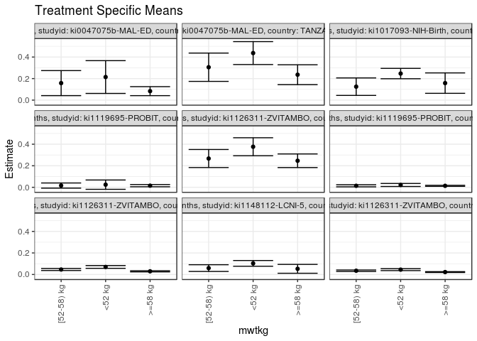

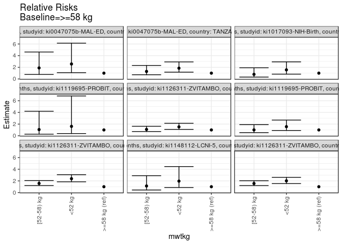

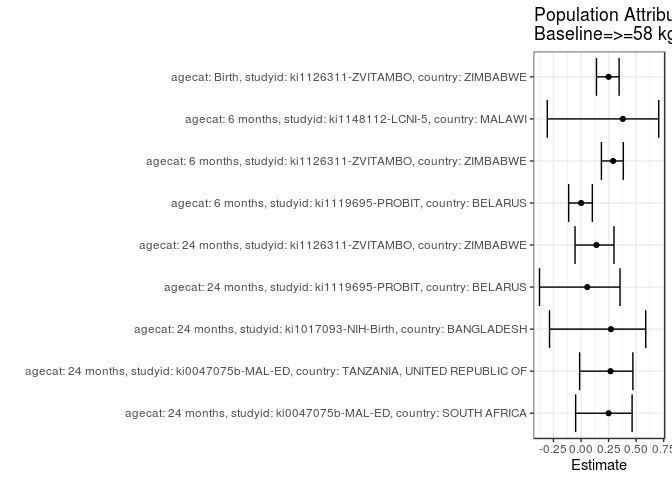

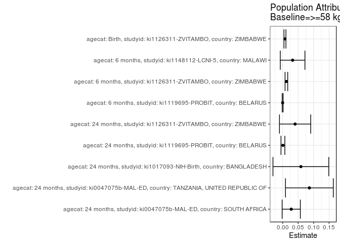

## Results Table

### Parameter: TSM

| agecat | studyid | country | intervention_level | baseline_level | estimate | ci_lower | ci_upper |
| --- | --- | --- | --- | --- | --- | --- | --- |
| Birth | ki1126311-ZVITAMBO | ZIMBABWE | >=58 kg | NA | 0.0224554 | 0.0185612 | 0.0263496 |
| Birth | ki1126311-ZVITAMBO | ZIMBABWE | <52 kg | NA | 0.0450531 | 0.0362239 | 0.0538823 |
| Birth | ki1126311-ZVITAMBO | ZIMBABWE | [52-58) kg | NA | 0.0349182 | 0.0279013 | 0.0419351 |
| 6 months | ki1119695-PROBIT | BELARUS | >=58 kg | NA | 0.0139138 | 0.0091224 | 0.0187052 |
| 6 months | ki1119695-PROBIT | BELARUS | <52 kg | NA | 0.0216954 | 0.0077233 | 0.0356675 |
| 6 months | ki1119695-PROBIT | BELARUS | [52-58) kg | NA | 0.0140451 | 0.0043767 | 0.0237136 |
| 6 months | ki1126311-ZVITAMBO | ZIMBABWE | >=58 kg | NA | 0.0295316 | 0.0243399 | 0.0347232 |
| 6 months | ki1126311-ZVITAMBO | ZIMBABWE | <52 kg | NA | 0.0701557 | 0.0572977 | 0.0830137 |
| 6 months | ki1126311-ZVITAMBO | ZIMBABWE | [52-58) kg | NA | 0.0462915 | 0.0369255 | 0.0556574 |
| 6 months | ki1148112-LCNI-5 | MALAWI | >=58 kg | NA | 0.0526316 | 0.0116170 | 0.0936461 |
| 6 months | ki1148112-LCNI-5 | MALAWI | <52 kg | NA | 0.1031746 | 0.0766021 | 0.1297471 |
| 6 months | ki1148112-LCNI-5 | MALAWI | [52-58) kg | NA | 0.0593607 | 0.0280461 | 0.0906753 |
| 24 months | ki0047075b-MAL-ED | SOUTH AFRICA | >=58 kg | NA | 0.0833333 | 0.0414503 | 0.1252164 |
| 24 months | ki0047075b-MAL-ED | SOUTH AFRICA | <52 kg | NA | 0.2142857 | 0.0619759 | 0.3665956 |
| 24 months | ki0047075b-MAL-ED | SOUTH AFRICA | [52-58) kg | NA | 0.1578947 | 0.0417089 | 0.2740806 |
| 24 months | ki0047075b-MAL-ED | TANZANIA, UNITED REPUBLIC OF | >=58 kg | NA | 0.2360527 | 0.1438313 | 0.3282741 |
| 24 months | ki0047075b-MAL-ED | TANZANIA, UNITED REPUBLIC OF | <52 kg | NA | 0.4368798 | 0.3304528 | 0.5433068 |
| 24 months | ki0047075b-MAL-ED | TANZANIA, UNITED REPUBLIC OF | [52-58) kg | NA | 0.3054908 | 0.1740492 | 0.4369324 |
| 24 months | ki1017093-NIH-Birth | BANGLADESH | >=58 kg | NA | 0.1578947 | 0.0631218 | 0.2526677 |
| 24 months | ki1017093-NIH-Birth | BANGLADESH | <52 kg | NA | 0.2467532 | 0.1985496 | 0.2949569 |
| 24 months | ki1017093-NIH-Birth | BANGLADESH | [52-58) kg | NA | 0.1250000 | 0.0438808 | 0.2061192 |
| 24 months | ki1119695-PROBIT | BELARUS | >=58 kg | NA | 0.0152773 | 0.0048389 | 0.0257157 |
| 24 months | ki1119695-PROBIT | BELARUS | <52 kg | NA | 0.0246154 | -0.0186703 | 0.0679010 |
| 24 months | ki1119695-PROBIT | BELARUS | [52-58) kg | NA | 0.0162482 | -0.0076028 | 0.0400991 |
| 24 months | ki1126311-ZVITAMBO | ZIMBABWE | >=58 kg | NA | 0.2464643 | 0.1832638 | 0.3096648 |
| 24 months | ki1126311-ZVITAMBO | ZIMBABWE | <52 kg | NA | 0.3766291 | 0.2930807 | 0.4601774 |
| 24 months | ki1126311-ZVITAMBO | ZIMBABWE | [52-58) kg | NA | 0.2672498 | 0.1835189 | 0.3509806 |

### Parameter: E(Y)

| agecat | studyid | country | intervention_level | baseline_level | estimate | ci_lower | ci_upper |
| --- | --- | --- | --- | --- | --- | --- | --- |
| Birth | ki1126311-ZVITAMBO | ZIMBABWE | NA | NA | 0.0299363 | 0.0267501 | 0.0331225 |
| 6 months | ki1119695-PROBIT | BELARUS | NA | NA | 0.0139272 | 0.0091775 | 0.0186768 |
| 6 months | ki1126311-ZVITAMBO | ZIMBABWE | NA | NA | 0.0416772 | 0.0372816 | 0.0460727 |
| 6 months | ki1148112-LCNI-5 | MALAWI | NA | NA | 0.0848268 | 0.0659398 | 0.1037138 |
| 24 months | ki0047075b-MAL-ED | SOUTH AFRICA | NA | NA | 0.1111111 | 0.0707584 | 0.1514638 |
| 24 months | ki0047075b-MAL-ED | TANZANIA, UNITED REPUBLIC OF | NA | NA | 0.3224299 | 0.2596598 | 0.3852000 |
| 24 months | ki1017093-NIH-Birth | BANGLADESH | NA | NA | 0.2167832 | 0.1777459 | 0.2558205 |
| 24 months | ki1119695-PROBIT | BELARUS | NA | NA | 0.0161974 | 0.0032099 | 0.0291848 |
| 24 months | ki1126311-ZVITAMBO | ZIMBABWE | NA | NA | 0.2866972 | 0.2442008 | 0.3291937 |

### Parameter: RR

| agecat | studyid | country | intervention_level | baseline_level | estimate | ci_lower | ci_upper |
| --- | --- | --- | --- | --- | --- | --- | --- |
| Birth | ki1126311-ZVITAMBO | ZIMBABWE | >=58 kg | >=58 kg | 1.0000000 | 1.0000000 | 1.000000 |
| Birth | ki1126311-ZVITAMBO | ZIMBABWE | <52 kg | >=58 kg | 2.0063403 | 1.5442855 | 2.606643 |
| Birth | ki1126311-ZVITAMBO | ZIMBABWE | [52-58) kg | >=58 kg | 1.5550041 | 1.1924810 | 2.027737 |
| 6 months | ki1119695-PROBIT | BELARUS | >=58 kg | >=58 kg | 1.0000000 | 1.0000000 | 1.000000 |
| 6 months | ki1119695-PROBIT | BELARUS | <52 kg | >=58 kg | 1.5592748 | 0.9036248 | 2.690650 |
| 6 months | ki1119695-PROBIT | BELARUS | [52-58) kg | >=58 kg | 1.0094396 | 0.5344617 | 1.906532 |
| 6 months | ki1126311-ZVITAMBO | ZIMBABWE | >=58 kg | >=58 kg | 1.0000000 | 1.0000000 | 1.000000 |
| 6 months | ki1126311-ZVITAMBO | ZIMBABWE | <52 kg | >=58 kg | 2.3756179 | 1.8428667 | 3.062381 |
| 6 months | ki1126311-ZVITAMBO | ZIMBABWE | [52-58) kg | >=58 kg | 1.5675253 | 1.1989692 | 2.049374 |
| 6 months | ki1148112-LCNI-5 | MALAWI | >=58 kg | >=58 kg | 1.0000000 | 1.0000000 | 1.000000 |
| 6 months | ki1148112-LCNI-5 | MALAWI | <52 kg | >=58 kg | 1.9603175 | 0.8627530 | 4.454166 |
| 6 months | ki1148112-LCNI-5 | MALAWI | [52-58) kg | >=58 kg | 1.1278539 | 0.4401123 | 2.890295 |
| 24 months | ki0047075b-MAL-ED | SOUTH AFRICA | >=58 kg | >=58 kg | 1.0000000 | 1.0000000 | 1.000000 |
| 24 months | ki0047075b-MAL-ED | SOUTH AFRICA | <52 kg | >=58 kg | 2.5714286 | 1.0767404 | 6.140983 |
| 24 months | ki0047075b-MAL-ED | SOUTH AFRICA | [52-58) kg | >=58 kg | 1.8947368 | 0.7772246 | 4.619035 |
| 24 months | ki0047075b-MAL-ED | TANZANIA, UNITED REPUBLIC OF | >=58 kg | >=58 kg | 1.0000000 | 1.0000000 | 1.000000 |
| 24 months | ki0047075b-MAL-ED | TANZANIA, UNITED REPUBLIC OF | <52 kg | >=58 kg | 1.8507720 | 1.1695091 | 2.928884 |
| 24 months | ki0047075b-MAL-ED | TANZANIA, UNITED REPUBLIC OF | [52-58) kg | >=58 kg | 1.2941633 | 0.7223962 | 2.318477 |
| 24 months | ki1017093-NIH-Birth | BANGLADESH | >=58 kg | >=58 kg | 1.0000000 | 1.0000000 | 1.000000 |
| 24 months | ki1017093-NIH-Birth | BANGLADESH | <52 kg | >=58 kg | 1.5627706 | 0.8313053 | 2.937852 |
| 24 months | ki1017093-NIH-Birth | BANGLADESH | [52-58) kg | >=58 kg | 0.7916667 | 0.3270664 | 1.916235 |
| 24 months | ki1119695-PROBIT | BELARUS | >=58 kg | >=58 kg | 1.0000000 | 1.0000000 | 1.000000 |
| 24 months | ki1119695-PROBIT | BELARUS | <52 kg | >=58 kg | 1.6112375 | 0.3803958 | 6.824696 |
| 24 months | ki1119695-PROBIT | BELARUS | [52-58) kg | >=58 kg | 1.0635476 | 0.2689766 | 4.205323 |
| 24 months | ki1126311-ZVITAMBO | ZIMBABWE | >=58 kg | >=58 kg | 1.0000000 | 1.0000000 | 1.000000 |
| 24 months | ki1126311-ZVITAMBO | ZIMBABWE | <52 kg | >=58 kg | 1.5281283 | 1.0894648 | 2.143416 |
| 24 months | ki1126311-ZVITAMBO | ZIMBABWE | [52-58) kg | >=58 kg | 1.0843346 | 0.7228124 | 1.626676 |

### Parameter: PAR

| agecat | studyid | country | intervention_level | baseline_level | estimate | ci_lower | ci_upper |
| --- | --- | --- | --- | --- | --- | --- | --- |
| Birth | ki1126311-ZVITAMBO | ZIMBABWE | >=58 kg | NA | 0.0074809 | 0.0043164 | 0.0106455 |
| 6 months | ki1119695-PROBIT | BELARUS | >=58 kg | NA | 0.0000134 | -0.0014805 | 0.0015072 |
| 6 months | ki1126311-ZVITAMBO | ZIMBABWE | >=58 kg | NA | 0.0121456 | 0.0078297 | 0.0164615 |
| 6 months | ki1148112-LCNI-5 | MALAWI | >=58 kg | NA | 0.0321952 | -0.0075626 | 0.0719530 |
| 24 months | ki0047075b-MAL-ED | SOUTH AFRICA | >=58 kg | NA | 0.0277778 | -0.0016109 | 0.0571664 |
| 24 months | ki0047075b-MAL-ED | TANZANIA, UNITED REPUBLIC OF | >=58 kg | NA | 0.0863772 | 0.0092039 | 0.1635504 |
| 24 months | ki1017093-NIH-Birth | BANGLADESH | >=58 kg | NA | 0.0588885 | -0.0312171 | 0.1489941 |
| 24 months | ki1119695-PROBIT | BELARUS | >=58 kg | NA | 0.0009200 | -0.0052791 | 0.0071192 |
| 24 months | ki1126311-ZVITAMBO | ZIMBABWE | >=58 kg | NA | 0.0402329 | -0.0102024 | 0.0906682 |

### Parameter: PAF

| agecat | studyid | country | intervention_level | baseline_level | estimate | ci_lower | ci_upper |
| --- | --- | --- | --- | --- | --- | --- | --- |
| Birth | ki1126311-ZVITAMBO | ZIMBABWE | >=58 kg | NA | 0.2498955 | 0.1401686 | 0.3456196 |
| 6 months | ki1119695-PROBIT | BELARUS | >=58 kg | NA | 0.0009593 | -0.1122258 | 0.1026263 |
| 6 months | ki1126311-ZVITAMBO | ZIMBABWE | >=58 kg | NA | 0.2914212 | 0.1850397 | 0.3839162 |
| 6 months | ki1148112-LCNI-5 | MALAWI | >=58 kg | NA | 0.3795404 | -0.3062459 | 0.7052851 |
| 24 months | ki0047075b-MAL-ED | SOUTH AFRICA | >=58 kg | NA | 0.2500000 | -0.0488300 | 0.4636881 |
| 24 months | ki0047075b-MAL-ED | TANZANIA, UNITED REPUBLIC OF | >=58 kg | NA | 0.2678945 | -0.0127056 | 0.4707460 |
| 24 months | ki1017093-NIH-Birth | BANGLADESH | >=58 kg | NA | 0.2716469 | -0.2857423 | 0.5873992 |
| 24 months | ki1119695-PROBIT | BELARUS | >=58 kg | NA | 0.0568020 | -0.3768638 | 0.3538776 |
| 24 months | ki1126311-ZVITAMBO | ZIMBABWE | >=58 kg | NA | 0.1403325 | -0.0542711 | 0.2990149 |